# Exercises

## Analyzing longitudinal data: Risperidone vs. haloperidol and schizophrenia

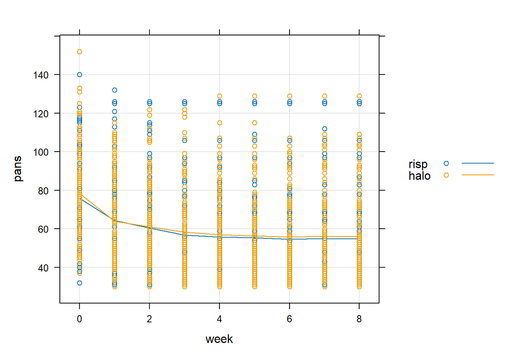

```r
dat       <- read.table("../data/moeller.csv", header = TRUE, sep = ",")
dat$id    <- factor(dat$id)
dat$treat <- factor(dat$treat, levels = c("risp", "halo"))

lattice::xyplot(pans ~ week, data = dat, groups = treat, type = c("g", "p", "a"), auto.key = TRUE)
```

1. Analyze the original data from moeller.csv:
   - `pans`: Positive and Negative Symptom Scale for schizophrenia
   - `treat`: medication group
     - `risp`: atypical neuroleptic risperidone
     - `halo`: conventional neuroleptic haloperidol
   - What is the sample size in each treatment group?
   - Estimate the by-group random-slope model.
   - What are the estimates for the fixed effects and variance components?
   - Interpret the interaction effect.
   - Test the interaction effect.
2. Run a power simulation for a replication study:
   - Set up a data frame containing the study design and sample size.
   - Specify the minimum relevant effect.
   - Set the fixed effects and variance components to plausible values.
   - How many participants are required for the test of the interaction to detect the specified effect with a power of 80%?
   - Recover the parameters of the by-group random-slope model for one simulated data set.
3. Create a renderable R script or an R Markdown file that includes
   - a header with title, author, date
   - at least one section head line
   - the questions from above and your answers
   - the R code, output, and plots (if any)

   Render the R or Rmd file to HTML.